# Urban Heat Island Data Challenge: Ernst & Young

Submitted By: Emily Brunner Himanshu Bundel Vinicius Cauneto Kelyan Edou Engone Victoria Angela Mendoza

April 25th, 2025 BCH-7815 Business Challenge III Prof. Chase Kusterer

Master of Business Analytics Hult International Business School

## 1. Introduction

The Urban Heat Island (UHI) Data Challenge, hosted by EY, focuses on predicting patterns of urban heat using satellite imagery and geospatial analysis. UHI refers to the phenomenon where urban areas experience higher temperatures than surrounding rural zones due to factors like surface materials, building density, and lack of vegetation. While the challenge is open in terms of how results are applied, our team chose to frame our analysis from a public health perspective, recognizing that extreme urban heat disproportionately affects vulnerable populations — including the elderly, young children, outdoor workers, and underserved communities.

The dataset provided includes over 34,000 observations from Montgomery County, Maryland, with UHI index values derived from ground-based temperature data. Predictor variables are sourced from satellite data, including Sentinel-2 spectral bands, Landsat-derived land surface temperature (LST), and digital elevation data. We also engineered features such as the Enhanced Vegetation Index (EVI), Modified Normalized Difference Water Index (MNDWI), and Normalized Difference Impervious Surface Index (NDISI) to better represent vegetation health, surface moisture, and built environments.

## 2. Analysis and Code

Our modeling workflow began with preparing a dataset combining Sentinel-2 spectral bands, Landsat-derived land surface temperature (LST), and elevation data. To improve environmental interpretability, we engineered several features: the Enhanced Vegetation Index (EVI), Modified Normalized Difference Water Index (MNDWI), and Normalized Difference Impervious Surface Index (NDISI). These features captured vegetation health, surface water, and urban impermeability, which are key contributors to UHI intensity.

While the model performed well, it is important to note some limitations. First, the data was based on a single collection date, and does not account for daily or even seasonal variations. Second, the model does not include human-centric variables such as building density, cooling infrastructure, or energy usage, which may further influence local temperature variability. Including such features in future iterations could enhance accuracy in heat resilience planning.

Overall, this model provides a scalable, interpretable tool for identifying UHI hotspots using open-access satellite data—supporting data-driven public health planning and climate adaptation.

### 2. Use High-LST and High-NDISI Zones to Direct Emergency Cooling Services

Areas with high predicted UHI values, particularly those marked by elevated LST and impervious surface coverage (NDISI), align with high-risk zones for heat stress. We recommend public health officials incorporate these model outputs into summer preparedness and emergency response strategies. Specific interventions might include mobile cooling stations, public misting tents, and targeted outreaches during heatwaves. Priority should be given to low-lying areas with dense infrastructure and little access to shade or ventilation. Cross-referencing UHI predictions with demographic data can help ensure life-saving resources reach at-risk populations like older adults, outdoor workers, and low-income families. This approach aligns with strategies outlined in heat and air quality resilience plans, similar to that of San Francisco, which emphasizes targeted interventions in vulnerable neighborhoods (City and County of San Francisco, 2023).

## 4. Conclusion

These findings provide not just predictive value but clear guidance for public health and urban planning. While the model doesn’t account for social or temporal variables, it offers a scalable, interpretable tool that cities can use to target heat mitigation where it's needed most. With climate change increasing urban heat risks, models like this can support more equitable and proactive responses.

## 5. Reflection on the Challenge

Working on this challenge was both rewarding and humbling. One of the biggest hurdles was dealing with unfamiliar data formats, especially the large TIFF files. The steep learning curve, tight timeline, and long code execution times made debugging difficult and time-consuming. Many of us had to invest extra hours doing trial and error just to get basic preprocessing to work, especially since the large datasets couldn’t easily be split across machines.

To manage execution time and system limitations, we had to simplify the model and reduce the size of the input data. That meant removing several of the engineered features we had initially included in earlier versions of the model. Interestingly, this simplification led to a drastic improvement in performance: our R² score rose significantly once the model focused on fewer, more predictive features. At the same time, this came at the cost of interpretability and granularity. With fewer variables in the mix, more of the variation was explained by intercepts, making it harder to pinpoint specific environmental drivers behind UHI effects.

We also lost some depth in understanding how the UHI index works at a finer scale, insights we had originally hoped to preserve. That said, the challenge still pushed us to think critically about how to balance accuracy, complexity, and feasibility in applied modeling. Even in its simplified form, this project underscored the value of data science for public health, and reminded us that technical trade-offs are often an unavoidable part of real-world work.

## Bibliography

City and County of San Francisco. (2023). Heat and Air Quality Resilience Plan. Retrieved from https://www.sf.gov/news--san-francisco-releases-plan-prepare-extreme-heat-and-air-quality-events

Emmanuel, R., & Krüger, E. (2012). Urban heat island and its impact on climate change resilience in a shrinking city: The case of Glasgow, UK. Building and Environment, 53, 137–149. https://doi.org/10.1016/j.buildenv.2012.01.020

Gunawardena, K. R., Wells, M. J., & Kershaw, T. (2017). Utilising green and bluespace to mitigate urban heat island intensity. Science of The Total Environment, 584–585, 1040–1055. https://doi.org/10.1016/j.scitotenv.2017.01.158

Kumar, P., et al. (2024). Urban heat mitigation by green and blue infrastructure: Drivers, effectiveness, and future needs. *Environmental Challenges, 11*, 100263. https://doi.org/10.1016/j.envc.2024.100263

Liu, Z., Zhang, W., & Tang, Q. (2024). Remote sensing of water bodies in urban areas using MNDWI: Implications for mitigating the urban heat island effect. Scientific Reports, 14, Article 2399. https://doi.org/10.1038/s41598-025-86199-1

Norton, B. A., Coutts, A. M., Livesley, S. J., Harris, R. J., Hunter, A. M., & Williams, N. S. G. (2015). Planning for cooler cities: A framework to prioritise green infrastructure to mitigate high temperatures in urban landscapes. Landscape and Urban Planning, 134, 127–138. https://doi.org/10.1016/j.landurbplan.2014.10.018

Qin, Z., Li, W., Li, Y., Zhao, S., Yang, L., & Zhang, L. (2018). Impacts of vegetation coverage and urbanization on urban heat islands: An empirical study based on remote sensing data. Journal of Geographical Sciences, 28(12), 1903–1916. https://doi.org/10.1007/s11707-018-0729-5

Weng, Q., Lu, D., & Schubring, J. (2004). Estimation of land surface temperature–vegetation abundance relationship for urban heat island studies. Remote Sensing of Environment, 89(4), 467–483. https://www.researchgate.net/publication/222550615_Comparison_of_impervious_surface_area_and_Normalized_Difference_Vegetation_Index_as_indicators_of_surface_Urban_Heat_Island_effects_in_Landsat_Imagery

# Model

## Libraries import

```python
# Supress Warnings
import warnings
warnings.filterwarnings('ignore')

# Visualization
import matplotlib.pyplot as plt
import seaborn as sns

# Data Science
import numpy as np
import pandas as pd
from scipy.ndimage import distance_transform_edt
import statsmodels.api as sm
import statsmodels.formula.api as smf

# Multi-dimensional arrays and datasets
import xarray as xr

# Geospatial raster data handling
import rioxarray as rxr

# Geospatial data analysis
import geopandas as gpd
from shapely.geometry import Point

# Geospatial operations
import rasterio
from rasterio import windows
from rasterio import features
from rasterio import warp
from rasterio.warp import transform_bounds
from rasterio.windows import from_bounds

# Image Processing
from PIL import Image

# Coordinate transformations
from pyproj import Proj, Transformer, CRS

# Feature Engineering
from sklearn.preprocessing import StandardScaler
from sklearn.model_selection import train_test_split

# Machine Learning
from sklearn.ensemble import RandomForestRegressor, GradientBoostingRegressor, AdaBoostRegressor, BaggingRegressor
from sklearn.metrics import r2_score, mean_squared_error, root_mean_squared_error
from sklearn.model_selection import cross_val_score, GridSearchCV, RandomizedSearchCV
from xgboost import XGBRegressor

# Planetary Computer Tools
import pystac_client
import planetary_computer as pc
from pystac.extensions.eo import EOExtension as eo

# Others
import os
from tqdm import tqdm

import folium
from folium.plugins import HeatMap
```

## User defined functions

```python
# Extracts satellite band values from a GeoTIFF based on coordinates from a csv file and returns them in a DataFrame.
def map_satellite_data_multi_revised(sentinel_path, landsat_path, dem_path, csv_path):
    """
    Maps satellite data from three different GeoTIFF files to coordinates in a CSV file.
    (Includes revised DEM extraction using coordinate transformation)
    """
    # --- Read CSV and Initialize (Keep your existing code) ---
    df_coords = pd.read_csv(csv_path)
    latitudes = df_coords['Latitude'].values
    longitudes = df_coords['Longitude'].values
    results = {}

    # --- Process Sentinel-2 (Keep your existing code, assuming it works) ---
    if sentinel_path:
        print("Processing Sentinel-2 data...")
        sentinel_data = rxr.open_rasterio(sentinel_path)
        sentinel_crs = sentinel_data.rio.crs

        # Get resolution in degrees
        s_resolution_x, s_resolution_y = sentinel_data.rio.resolution()
        s_resolution_x, s_resolution_y = abs(s_resolution_x), abs(s_resolution_y)

        # Calculate bbox size for Sentinel-2 (10m resolution)
        s_lon_offset = s_resolution_x * 50  # 50 pixel offset (100x100 box)
        s_lat_offset = s_resolution_y * 50

        # Create transformer for Sentinel-2
        proj_wgs84 = Proj(init='epsg:4326')
        proj_sentinel = Proj(sentinel_crs)
        sentinel_transformer = Transformer.from_proj(proj_wgs84, proj_sentinel)

        # Initialize arrays for Sentinel-2 bands
        sentinel_bands = {
            'B01': [], 'B02': [], 'B03': [], 'B04': [], 'B05': [],
            'B06': [], 'B07': [], 'B08': [], 'B8A': [], 'B11': [], 'B12': []
        }

        # Extract Sentinel-2 values
        for lat, lon in tqdm(zip(latitudes, longitudes), total=len(latitudes), desc="Processing Sentinel-2"):
            bbox = {
                "x": slice(lon - s_lon_offset, lon + s_lon_offset),
                "y": slice(lat + s_lat_offset, lat - s_lat_offset),
            }

            # Map band indices to names
            band_mapping = {
                1: 'B01', 2: 'B02', 3: 'B03', 4: 'B04', 5: 'B05',
                6: 'B06', 7: 'B07', 8: 'B08', 9: 'B8A', 10: 'B11', 11: 'B12'
            }

            # Extract values for each band
            for band_idx, band_name in band_mapping.items():
                try:
                    sentinel_bands[band_name].append(np.nanmedian(sentinel_data.sel(band=band_idx, **bbox).values))
                except Exception as e:
                    print(f"Error extracting Sentinel-2 {band_name}: {e}")
                    sentinel_bands[band_name].append(np.nan)

        # Add Sentinel bands to results
        for band_name, values in sentinel_bands.items():
            results[f"{band_name}"] = values

    # --- Process Landsat (Keep your existing code, assuming it works) ---
    if landsat_path:
        print("Processing Landsat LST data (Band 11)...")
        landsat_data = rxr.open_rasterio(landsat_path)
        landsat_crs = landsat_data.rio.crs

        # Get resolution in degrees
        l_resolution_x, l_resolution_y = landsat_data.rio.resolution()
        l_resolution_x, l_resolution_y = abs(l_resolution_x), abs(l_resolution_y)

        # Calculate bbox size for Landsat (30m resolution)
        l_lon_offset = l_resolution_x * 17
        l_lat_offset = l_resolution_y * 17

        # Create transformer for Landsat
        proj_landsat = Proj(landsat_crs)
        landsat_transformer = Transformer.from_proj(proj_wgs84, proj_landsat)

        # Initialize arrays for Landsat B11 (LST) band
        lst_values = []

        # Extract Landsat LST values
        for lat, lon in tqdm(zip(latitudes, longitudes), total=len(latitudes), desc="Processing Landsat LST"):
            bbox = {
                "x": slice(lon - l_lon_offset, lon + l_lon_offset),
                "y": slice(lat + l_lat_offset, lat - l_lat_offset),
            }

            try:
                # For single band, check if we need to specify band parameter
                if landsat_data.rio.count > 1:
                    # If multi-band for some reason, get the first band
                    lst_values.append(np.nanmedian(landsat_data.sel(band=1, **bbox).values))
                else:
                    # If single band, we don't specify band
                    lst_values.append(np.nanmedian(landsat_data.sel(**bbox).values))
            except Exception as e:
                print(f"Error extracting Landsat LST: {e}")
                lst_values.append(np.nan)

        # Add Landsat LST to results
        results["Land Surface Temperature"] = lst_values

    # --- Process DEM data (REVISED) ---
    if dem_path:
        print("Processing DEM data (Revised Method)...")
        try:
            dem_data = rxr.open_rasterio(dem_path, masked=True).squeeze() # Open, ensure single band if squeezed, mask NoData
            dem_crs = dem_data.rio.crs
            print(f"DEM CRS: {dem_crs}")

            # Create GeoDataFrame from points (assuming WGS84 input)
            geometry = [Point(lon, lat) for lon, lat in zip(longitudes, latitudes)]
            gdf_coords = gpd.GeoDataFrame(df_coords, geometry=geometry, crs="EPSG:4326")

            # Transform coordinates to DEM's CRS
            print("Transforming coordinates to DEM CRS...")
            gdf_coords_proj = gdf_coords.to_crs(4326)

            # Initialize array for DEM elevation
            dem_values = []

            print("Extracting DEM values using transformed coordinates...")
            # Extract DEM values using transformed coordinates
            for point_proj in tqdm(gdf_coords_proj.geometry, total=len(gdf_coords_proj), desc="Processing DEM"):
                try:
                    # Extract the value at the nearest pixel to the transformed point
                    # Use sel with method='nearest'
                    value = dem_data.sel(x=point_proj.x, y=point_proj.y, method="nearest").item()
                    dem_values.append(value)
                except Exception as e:
                    # Handle points potentially outside the raster extent or other errors
                    # print(f"Warning: Could not extract DEM for point {point_proj.x, point_proj.y}. Error: {e}")
                    dem_values.append(np.nan)

            # Add DEM elevation to results
            results["Elevation"] = dem_values

        except Exception as e:
            print(f"FATAL ERROR processing DEM file: {e}")
            # Add NaNs if the entire DEM processing fails
            results["Elevation"] = [np.nan] * len(latitudes)


    # --- Create Final DataFrame (Keep your existing code) ---
    final_df = pd.DataFrame(results)
    final_df['Latitude'] = latitudes
    final_df['Longitude'] = longitudes

    return final_df

# Combine two datasets vertically (along columns) using pandas concat function.
def combine_two_datasets(dataset1,dataset2):
    '''
    Returns a  vertically concatenated dataset.
    Attributes:
    dataset1 - Dataset 1 to be combined
    dataset2 - Dataset 2 to be combined
    '''

    data = pd.concat([dataset1,dataset2], axis=1)
    return data

## Stepwise Selection for OLS Regression ##
def ols_stepwise_selection(x_data,
                           y_data,
                           initial_list  = [],
                           threshold_in  = 0.01,
                           threshold_out = 0.05,
                           verbose       = True):
    """
    Perform a forward-backward feature selection based on p-values from statsmodels.api.OLS.

    Arguments:
        x_data : pandas.DataFrame
            DataFrame with candidate features.
        y_data : array-like
            The target variable.
        initial_list : list
            List of features (column names of x) to start with.
        threshold_in : float
            Include a feature if its p-value < threshold_in.
        threshold_out : float
            Exclude a feature if its p-value > threshold_out.
        verbose : bool
            Whether to print the sequence of inclusions and exclusions.

    Returns:
        list
            The list of selected features.

    Note: Always set threshold_in < threshold_out to avoid infinite loops.
    """

    # required imports
    import statsmodels.api as sm
    import pandas as pd


    # setting placeholer list
    included = list(initial_list)


    # looping over each x-feature until there are no more significant p-values
    while True:
        changed = False

        # forward step: adding an x-feature
        excluded = [col for col in x_data.columns if col not in included]
        new_pvals = pd.Series(dtype = float, index = excluded)


        # fitting model with additional candidate feature
        for new_column in excluded:

            model = sm.OLS(y_data,
                           sm.add_constant(x_data[included + [new_column]])).fit()

            new_pvals[new_column] = model.pvalues[new_column]


        if not new_pvals.empty:
            best_pval = new_pvals.min()
            if best_pval < threshold_in:
                best_feature = new_pvals.idxmin()  # Use idxmin() instead of argmin()
                included.append(best_feature)
                changed = True
                if verbose:
                    print('Add  {:30} with p-value {:.6}'.format(best_feature, best_pval))


        # backward step: potentially removing an x-feature
        if included:
            model = sm.OLS(y_data, sm.add_constant(x_data[included])).fit()

            # excluding intercept p-value (first element)
            pvals = model.pvalues.iloc[1:]

            # ensuring the model is not empty
            if not pvals.empty:
                worst_pval = pvals.max()
                if worst_pval > threshold_out:
                    worst_feature = pvals.idxmax()  # Use idxmax() instead of argmax()
                    included.remove(worst_feature)
                    changed = True
                    if verbose:
                        print('Drop {:30} with p-value {:.6}'.format(worst_feature, worst_pval))


        # stopping the loop if optimized
        if not changed:
            break


    # returning stepwise model's x-features
    return included
```

## Inspecting the training data

```python
# Load the training data from csv file and display the first few rows to inspect the data
ground_df = pd.read_csv("./Training_Data_Hult_Maryland.csv")

# Open the GeoTIFF file
sentinel_path = './Maryland_S2_2.tiff'

# Read the bands from the GeoTIFF file
with rasterio.open(sentinel_path) as src1:
    band1  = src1.read(1)   # Band [B01]
    band2  = src1.read(2)   # Band [B02]
    band3  = src1.read(3)   # Band [B03]
    band4  = src1.read(4)   # Band [B04]
    band5  = src1.read(5)   # Band [B05]
    band6  = src1.read(6)   # Band [B06]
    band7  = src1.read(7)   # Band [B07]
    band8  = src1.read(8)   # Band [B08]
    band9  = src1.read(9)   # Band [B8A]
    band10 = src1.read(10)  # Band [B011]
    band11 = src1.read(11)  # Band [B012]

# Open the Landsat GeoTIFF file
landsat_path = './Maryland_LST_2.tiff'

with rasterio.open(landsat_path) as src2:
    band2  = src2.read(1)   # Band [B11]

# Open the DEM GeoTIFF file
dem_path = 'Maryland_DEM_2.tiff'

with rasterio.open(dem_path) as src3:
    dem_band = src3.read(1)  # Band [Elevation]
```

```python
# # Load the training data from csv file and display the first few rows to inspect the data
# ground_df = pd.read_csv("./Training_Data_Hult_NYC.csv")

# # Open the GeoTIFF file
# sentinel_path = './NYC_S2.tiff'

# # Read the bands from the GeoTIFF file
# with rasterio.open(sentinel_path) as src1:
#     band1  = src1.read(1)   # Band [B01]
#     band2  = src1.read(2)   # Band [B02]
#     band3  = src1.read(3)   # Band [B03]
#     band4  = src1.read(4)   # Band [B04]
#     band5  = src1.read(5)   # Band [B05]
#     band6  = src1.read(6)   # Band [B06]
#     band7  = src1.read(7)   # Band [B07]
#     band8  = src1.read(8)   # Band [B08]
#     band9  = src1.read(9)   # Band [B8A]
#     band10 = src1.read(10)  # Band [B011]
#     band11 = src1.read(11)  # Band [B012]

# # Open the Landsat GeoTIFF file
# landsat_path = './NYC_LST.tiff'

# with rasterio.open(landsat_path) as src2:
#     band2  = src2.read(1)   # Band [B11]

# # Open the DEM GeoTIFF file
# dem_path = 'NYC_DEM.tiff'

# with rasterio.open(dem_path) as src3:
#     dem_band = src3.read(1)  # Band [Elevation]
```

## Loading, Processing and merging the Training Data

```python
# defining paths for tiff files
sentinel_path = './Maryland_S2_2.tiff'
landsat_path  = './Maryland_LST_2.tiff'
dem_path      = './Maryland_DEM_2.tiff'
csv_path      = './Training_Data_Hult_Maryland.csv'

# Mapping 10m satellite data with training data.
final_data = map_satellite_data_multi_revised(sentinel_path, landsat_path, dem_path, csv_path)
```

```
Processing Sentinel-2 data...
```

```
Processing Landsat LST data (Band 11)...
```

```
Processing DEM data (Revised Method)...
DEM CRS: EPSG:4326
Transforming coordinates to DEM CRS...
Extracting DEM values using transformed coordinates...
```

```python
# # defining paths for tiff files
# sentinel_path = './NYC_S2.tiff'
# landsat_path  = './NYC_LST.tiff'
# dem_path      = './NYC_DEM.tiff'
# csv_path      = './Training_Data_Hult_NYC.csv'

# # Mapping 10m satellite data with training data.
# final_data = map_satellite_data_multi_revised(sentinel_path, landsat_path, dem_path, csv_path)
```

```python
final_data.head()
```

|  | B01 | B02 | B03 | B04 | B05 | B06 | B07 | B08 | B8A | B11 | B12 | Land Surface Temperature | Elevation | Latitude | Longitude |
| --- | --- | --- | --- | --- | --- | --- | --- | --- | --- | --- | --- | --- | --- | --- | --- |
| 0 | 1138.0 | 1173.0 | 1373.0 | 1335.0 | 1797.0 | 2725.0 | 3061.0 | 3310.0 | 3387.0 | 2525.0 | 1788.0 | 20.392084 | 85.45948 | 39.109905 | -77.302700 |
| 1 | 1138.0 | 1174.0 | 1374.0 | 1335.0 | 1797.0 | 2727.0 | 3063.0 | 3313.0 | 3389.0 | 2525.0 | 1790.0 | 20.392084 | 85.45948 | 39.109855 | -77.302690 |
| 2 | 1138.0 | 1174.0 | 1374.0 | 1334.5 | 1796.0 | 2726.0 | 3063.0 | 3314.0 | 3388.0 | 2524.0 | 1788.0 | 20.392084 | 85.45948 | 39.109960 | -77.302677 |
| 3 | 1138.0 | 1173.0 | 1374.0 | 1335.0 | 1797.0 | 2727.0 | 3063.0 | 3314.0 | 3389.0 | 2526.0 | 1790.0 | 20.392084 | 85.45948 | 39.109808 | -77.302655 |
| 4 | 1138.0 | 1174.0 | 1374.0 | 1334.5 | 1796.0 | 2726.0 | 3063.0 | 3314.0 | 3388.0 | 2524.0 | 1788.0 | 20.392084 | 85.45948 | 39.110017 | -77.302630 |

```python
final_data.info()
```

```
<class 'pandas.core.frame.DataFrame'>
RangeIndex: 34502 entries, 0 to 34501
Data columns (total 15 columns):
 #   Column                    Non-Null Count  Dtype
---  ------                    --------------  -----
 0   B01                       34502 non-null  float64
 1   B02                       34502 non-null  float64
 2   B03                       34502 non-null  float64
 3   B04                       34502 non-null  float64
 4   B05                       34502 non-null  float64
 5   B06                       34502 non-null  float64
 6   B07                       34502 non-null  float64
 7   B08                       34502 non-null  float64
 8   B8A                       34502 non-null  float64
 9   B11                       34502 non-null  float64
 10  B12                       34502 non-null  float64
 11  Land Surface Temperature  34402 non-null  float64
 12  Elevation                 34502 non-null  float64
 13  Latitude                  34502 non-null  float64
 14  Longitude                 34502 non-null  float64
dtypes: float64(15)
memory usage: 3.9 MB
```

## Feature engineering

### Normalized Difference Indexes, for vegetation (EVI), water bodies (MNDWI) and Impervious Surfaces (NDISI)

```python
# Calculate EVI
G = 2.5; C1 = 6.0; C2 = 7.5; L = 1.0

final_data['EVI'] = G * ((final_data['B08'] - final_data['B04']) / (final_data['B08'] + C1 * final_data['B04'] - C2 * final_data['B02'] + L))
final_data['EVI'] = final_data['EVI'].replace([np.inf, -np.inf], np.nan)


# Calculate MNDWI
final_data['MNDWI'] = (final_data['B03'] - final_data['B11']) / (final_data['B03'] + final_data['B11'])
final_data['MNDWI'] = final_data['MNDWI'].replace([np.inf, -np.inf], np.nan)

# Calculate the NDISI numerator
ndisi_numerator = (final_data['B11'] + final_data['B02']) - (final_data['B08'] + final_data['B04'])

# Calculate the NDISI denominator
ndisi_denominator = (final_data['B11'] + final_data['B02']) + (final_data['B08'] + final_data['B04'])

epsilon = 1e-9

# Calculate NDISI
final_data['NDISI'] = ndisi_numerator / (ndisi_denominator + epsilon)
final_data['NDISI'] = final_data['NDISI'].replace([np.inf, -np.inf], np.nan)
```

### Checking the feature complete DataFrame

```python
# Combining ground data and final data into a single dataset.
uhi_data = combine_two_datasets(ground_df,final_data)
#uhi_data = uhi_data.drop(columns=['B08', 'B07'], axis=1)
uhi_data.describe()
```

|  | Longitude | Latitude | UHI Index | B01 | B02 | B03 | B04 | B05 | B06 | B07 | ... | B8A | B11 | B12 | Land Surface Temperature | Elevation | Latitude | Longitude | EVI | MNDWI | NDISI |
| --- | --- | --- | --- | --- | --- | --- | --- | --- | --- | --- | --- | --- | --- | --- | --- | --- | --- | --- | --- | --- | --- |
| count | 34502.000000 | 34502.000000 | 34502.000000 | 34502.000000 | 34502.000000 | 34502.000000 | 34502.000000 | 34502.000000 | 34502.000000 | 34502.000000 | ... | 34502.000000 | 34502.000000 | 34502.000000 | 34402.000000 | 34502.000000 | 34502.000000 | 34502.000000 | 34502.000000 | 34502.000000 | 34502.000000 |
| mean | -77.134629 | 39.085676 | 0.999996 | 1290.065909 | 1309.351835 | 1504.864008 | 1480.951249 | 1898.918411 | 2694.052359 | 2959.553649 | ... | 3208.674526 | 2510.108921 | 1885.166222 | 17.326128 | 80.222738 | 39.085676 | -77.134629 | 1.881759 | -0.251250 | -0.096107 |
| std | 0.095707 | 0.056880 | 0.017190 | 152.559699 | 140.284589 | 133.439538 | 165.130592 | 120.800979 | 117.593521 | 149.662810 | ... | 189.883711 | 119.884086 | 136.716479 | 2.034375 | 3.241185 | 0.056880 | 0.095707 | 0.241281 | 0.035325 | 0.017446 |
| min | -77.302700 | 38.963932 | 0.913071 | 1058.000000 | 1108.000000 | 1273.000000 | 1243.000000 | 1705.000000 | 2340.000000 | 2480.000000 | ... | 2584.000000 | 2249.000000 | 1582.000000 | 12.555419 | 77.022919 | 38.963932 | -77.302700 | 1.021455 | -0.346417 | -0.147217 |
| 25% | -77.208001 | 39.044911 | 0.990263 | 1195.000000 | 1216.000000 | 1416.000000 | 1368.125000 | 1815.000000 | 2625.000000 | 2874.500000 | ... | 3106.000000 | 2441.500000 | 1790.000000 | 15.962330 | 77.022919 | 39.044911 | -77.208001 | 1.747726 | -0.273016 | -0.107280 |
| 50% | -77.149030 | 39.085253 | 1.001290 | 1257.000000 | 1273.000000 | 1467.000000 | 1430.000000 | 1866.500000 | 2684.000000 | 2952.000000 | ... | 3209.000000 | 2494.000000 | 1856.000000 | 16.915103 | 78.746063 | 39.085253 | -77.149030 | 1.923338 | -0.255859 | -0.098718 |
| 75% | -77.058958 | 39.122534 | 1.011215 | 1329.000000 | 1352.000000 | 1552.000000 | 1536.000000 | 1950.500000 | 2746.000000 | 3025.000000 | ... | 3296.000000 | 2551.000000 | 1950.000000 | 18.320551 | 82.246269 | 39.122534 | -77.058958 | 2.050467 | -0.234364 | -0.088335 |
| max | -76.929972 | 39.231637 | 1.054222 | 2005.000000 | 1912.000000 | 2078.000000 | 2168.000000 | 2437.000000 | 3638.000000 | 4201.000000 | ... | 4582.000000 | 3436.500000 | 2533.000000 | 26.865814 | 85.459480 | 39.231637 | -76.929972 | 2.495811 | -0.133607 | -0.029204 |

8 rows × 21 columns

#### Removing duplicate rows

```python
# Remove duplicate rows from the DataFrame based on specified columns and keep the first occurrence
columns_to_check = ['B01', 'B02', 'B03', 'B04', 'B05', 'B06', 'B8A', 'B11', 'B12']
for col in columns_to_check:
    # Check if the value is a numpy array and has more than one dimension
    uhi_data[col] = uhi_data[col].apply(lambda x: tuple(x) if isinstance(x, np.ndarray) and x.ndim > 0 else x)

# Now remove duplicates
uhi_data = uhi_data.drop_duplicates(subset=columns_to_check, keep='first')
#uhi_data = uhi_data.drop(columns=['Longitude', 'Latitude'], axis=1)

#Drop rows with NaN values in the specified columns
uhi_data = uhi_data.dropna()
uhi_data.head()
```

|  | Longitude | Latitude | UHI Index | B01 | B02 | B03 | B04 | B05 | B06 | B07 | ... | B8A | B11 | B12 | Land Surface Temperature | Elevation | Latitude | Longitude | EVI | MNDWI | NDISI |
| --- | --- | --- | --- | --- | --- | --- | --- | --- | --- | --- | --- | --- | --- | --- | --- | --- | --- | --- | --- | --- | --- |
| 0 | -77.302700 | 39.109905 | 0.993571 | 1138.0 | 1173.0 | 1373.0 | 1335.0 | 1797.0 | 2725.0 | 3061.0 | ... | 3387.0 | 2525.0 | 1788.0 | 20.392084 | 85.45948 | 39.109905 | -77.302700 | 1.956608 | -0.295536 | -0.113508 |
| 1 | -77.302690 | 39.109855 | 0.994674 | 1138.0 | 1174.0 | 1374.0 | 1335.0 | 1797.0 | 2727.0 | 3063.0 | ... | 3389.0 | 2525.0 | 1790.0 | 20.392084 | 85.45948 | 39.109855 | -77.302690 | 1.963081 | -0.295204 | -0.113694 |
| 2 | -77.302677 | 39.109960 | 0.993571 | 1138.0 | 1174.0 | 1374.0 | 1334.5 | 1796.0 | 2726.0 | 3063.0 | ... | 3388.0 | 2524.0 | 1788.0 | 20.392084 | 85.45948 | 39.109960 | -77.302677 | 1.966130 | -0.295023 | -0.113880 |
| 3 | -77.302655 | 39.109808 | 0.994674 | 1138.0 | 1173.0 | 1374.0 | 1335.0 | 1797.0 | 2727.0 | 3063.0 | ... | 3389.0 | 2526.0 | 1790.0 | 20.392084 | 85.45948 | 39.109808 | -77.302655 | 1.957468 | -0.295385 | -0.113800 |
| 6 | -77.302575 | 39.110082 | 0.993571 | 1138.0 | 1175.0 | 1374.0 | 1335.0 | 1795.0 | 2727.0 | 3064.0 | ... | 3388.0 | 2521.0 | 1788.0 | 20.340814 | 85.45948 | 39.110082 | -77.302575 | 1.969576 | -0.294480 | -0.114412 |

5 rows × 21 columns

#### Resetting the feature complete DataFrame's indexes

```python
# Resetting the index of the dataset
uhi_data=uhi_data.reset_index(drop=True)
```

## Candidate model preparation

### Defining predictor and target variables, and splitting the data into training and testing sets

```python
# Split the data into features (X) and target (y), and then into training and testing sets
X = uhi_data.drop(columns = ['UHI Index', 'Longitude', 'Latitude', 'B07', 'B08', 'B8A', 'B12', 'B05', 'B02'], axis=1).values
y = uhi_data ['UHI Index'].values
X_train, X_test, y_train, y_test = train_test_split(X, y, test_size=0.20, random_state=9, shuffle=True)
```

### Scaling variables values, Fitting and Predicting

```python
# Scale the training and test data using standardscaler
sc = StandardScaler()
X_train = sc.fit_transform(X_train)
X_test = sc.transform(X_test)

# Train the Random Forest model on the training data
model = RandomForestRegressor(n_estimators=300, random_state=42)
model.fit(X_train,y_train)

# Make predictions on the training data
insample_predictions = model.predict(X_train)

# Make predictions on the test data
outsample_predictions = model.predict(X_test)
```

```python
# calculate R-squared score for in-sample predictions
Y_train = y_train.tolist()
r2_score(Y_train, insample_predictions)
```

```
0.9911402662545964
```

```python
# calculate R-squared score for out-sample predictions
Y_test = y_test.tolist()
r2_score(Y_test, outsample_predictions)
```

```
0.9406655700241974
```

### Checking features importance

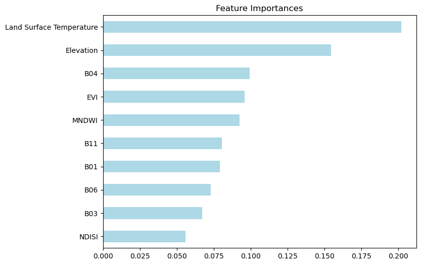

```python
# Create a pd.Series of feature importances
feature_names = uhi_data.drop(columns = ['UHI Index', 'Longitude', 'Latitude', 'B07', 'B08', 'B8A', 'B12', 'B05', 'B02'], axis=1).columns
importances = pd.Series(data=model.feature_importances_, index=feature_names)

# Sort importances
importances_sorted = importances.sort_values()
plt.figure(figsize=(8, 6))
# Draw a horizontal barplot of importances_sorted
importances_sorted.plot(kind='barh', color='lightblue')  # Color optional
plt.title('Feature Importances')
plt.show()
```

#### Tuned Random Forest Model

```python
from sklearn.metrics import r2_score

# INSTANTIATING a random forest model with default hyperparameters
model = RandomForestRegressor(    n_estimators=500,
                                    criterion='friedman_mse',
                                    max_depth=None,
                                    max_features=0.8,
                                    min_samples_leaf=1,
                                    min_samples_split=2,
                                    bootstrap=True,
                                    random_state=702,
                                    oob_score=True
                             )


model_fit = model.fit(X_train, y_train)

# In-sample predictions (training set)
train_preds = model.predict(X_train)
r2_train = r2_score(y_train, train_preds)
print(f"R² Score (Train): {r2_train:.4f}")

# Out-of-sample predictions (test set)
test_preds = model.predict(X_test)
r2_test = r2_score(y_test, test_preds)
print(f"R² Score (Test): {r2_test:.4f}")

# Print the GAP
train= r2_train
test=  r2_test
print(f"Gap: {train - test}")
```

```
R² Score (Train): 0.9914
R² Score (Test): 0.9411
Gap: 0.05023567797823225
```

## Predictions file generation (CSV)

```python
#Reading the coordinates for the submission
test_file = pd.read_csv('./Submission_Template_Hult_Maryland.csv')

# mapping the test data with the satellite data
Post_val_data = map_satellite_data_multi_revised(sentinel_path, landsat_path, dem_path, 'Submission_Template_Hult_Maryland.csv')
```

```
Processing Sentinel-2 data...
```

```
Processing Landsat LST data (Band 11)...
```

```
Processing DEM data (Revised Method)...
DEM CRS: EPSG:4326
Transforming coordinates to DEM CRS...
Extracting DEM values using transformed coordinates...
```

```python
G = 2.5; C1 = 6.0; C2 = 7.5; L = 1.0
# Using B08 (NIR), B04 (Red), B02 (Blue)
Post_val_data['EVI'] = G * ((Post_val_data['B08'] - Post_val_data['B04']) / (Post_val_data['B08'] + C1 * Post_val_data['B04'] - C2 * Post_val_data['B02'] + L))
Post_val_data['EVI'] = Post_val_data['EVI'].replace([np.inf, -np.inf], np.nan)

# Using B03 (Green) and B11 (SWIR 1)
Post_val_data['MNDWI'] = (Post_val_data['B03'] - Post_val_data['B11']) / (Post_val_data['B03'] + Post_val_data['B11'])
Post_val_data['MNDWI'] = Post_val_data['MNDWI'].replace([np.inf, -np.inf], np.nan)

# Calculate the NDISI numerator
ndisi_numerator = (Post_val_data['B11'] + Post_val_data['B02']) - (Post_val_data['B08'] + Post_val_data['B04'])

# Calculate the NDISI denominator
ndisi_denominator = (Post_val_data['B11'] + Post_val_data['B02']) + (Post_val_data['B08'] + Post_val_data['B04'])

epsilon = 1e-9

# Calculate NDISI
Post_val_data['NDISI'] = ndisi_numerator / (ndisi_denominator + epsilon)
Post_val_data['NDISI'] = Post_val_data['NDISI'].replace([np.inf, -np.inf], np.nan)

# Drop the columns that are not needed for prediction
Post_val_data = Post_val_data.drop(columns=['Longitude', 'Latitude', 'B07', 'B08', 'B8A', 'B12', 'B05', 'B02'], axis=1)

# Drop any missing values
val_data = Post_val_data.dropna().reset_index(drop=True)

# Select the same features used in training (15 total)
submission_val_data = Post_val_data

# Scale features using the same scaler from training
submission_scaled = sc.transform(submission_val_data.values)

# Make predictions using best model
final_predictions = model.predict(submission_scaled)

# Build final submission DataFrame
submission_df = pd.DataFrame({
    'Longitude': test_file['Longitude'],
    'Latitude': test_file['Latitude'],
    'UHI Index': final_predictions
})

#Displaying the sample submission dataframe
submission_df.head()
submission_df.describe()
```

|  | Longitude | Latitude | UHI Index |
| --- | --- | --- | --- |
| count | 3834.000000 | 3834.000000 | 3834.000000 |
| mean | -77.134710 | 39.085645 | 1.000098 |
| std | 0.095853 | 0.056595 | 0.016164 |
| min | -77.301697 | 38.964003 | 0.925625 |
| 25% | -77.207414 | 39.044883 | 0.991292 |
| 50% | -77.149144 | 39.085676 | 1.001329 |
| 75% | -77.059566 | 39.122264 | 1.010960 |
| max | -76.930010 | 39.231257 | 1.040709 |

```python
#Dumping the predictions into a csv file.
submission_df.to_csv("Predicted_Data_Hult_Maryland(with LST and Elevation).csv",index = False)
```